# FB-PROPHET

Prophet is a procedure for forecasting time series data based on an additive model where non-linear trends are fit with yearly, weekly, and daily seasonality, plus holiday effects. It works best with time series that have strong seasonal effects and several seasons of historical data. Prophet is robust to missing data and shifts in the trend, and typically handles outliers well.

## Goal:

### predictions for April, May, June, July, August, September 2021.

```python
conda install libpython m2w64-toolchain -c msys2
```

[output not shown]

[output cut: 98 more lines]

[output not shown]

```python
pip install pystan
```

```python
pip install fbprophet
```

```
  Using cached fbprophet-0.7.1.tar.gz (64 kB)
```

```python
import numpy as np # linear algebra
import pandas as pd # data processing, CSV file I/O (e.g. pd.read_csv)
# Import matplotlib, seaborn for visualization
import matplotlib.pyplot as plt
import seaborn as sns
import warnings
warnings.filterwarnings('ignore')
from fbprophet import Prophet
from sklearn.metrics import mean_squared_error
```

Reading the dataset

Export CSV File to a python Pandas DataFrame

```python
df = pd.read_csv('forecast.csv')
df.head()
```

|  | DATE | CC Volume |
| --- | --- | --- |
| 0 | 1/1/2017 | 31 |
| 1 | 1/2/2017 | 251 |
| 2 | 1/3/2017 | 518 |
| 3 | 1/4/2017 | 414 |
| 4 | 1/5/2017 | 420 |

```python
df.tail() # check the last rows from dataset
```

|  | DATE | CC Volume |
| --- | --- | --- |
| 1536 | 3/18/2021 | 559 |
| 1537 | 3/19/2021 | 507 |
| 1538 | 3/20/2021 | 105 |
| 1539 | 3/21/2021 | 52 |
| 1540 | 3/22/2021 | 402 |

```python
df.info() #check the basic information of our dataset like what type of coulmns is any column empty or not etc
```

```
<class 'pandas.core.frame.DataFrame'>
RangeIndex: 1541 entries, 0 to 1540
Data columns (total 2 columns):
 #   Column     Non-Null Count  Dtype
---  ------     --------------  -----
 0   DATE       1541 non-null   object
 1   CC Volume  1541 non-null   int64
dtypes: int64(1), object(1)
memory usage: 24.2+ KB
```

The Date coulmn have string(object) type of data changing its type into datetime

```python
df['DATE'] = pd.to_datetime(df['DATE']) # change the type of date column
```

```python
df
```

|  | DATE | CC Volume |
| --- | --- | --- |
| 0 | 2017-01-01 | 31 |
| 1 | 2017-01-02 | 251 |
| 2 | 2017-01-03 | 518 |
| 3 | 2017-01-04 | 414 |
| 4 | 2017-01-05 | 420 |
| ... | ... | ... |
| 1536 | 2021-03-18 | 559 |
| 1537 | 2021-03-19 | 507 |
| 1538 | 2021-03-20 | 105 |
| 1539 | 2021-03-21 | 52 |
| 1540 | 2021-03-22 | 402 |

1541 rows × 2 columns

```python
df = df.rename(columns={'CC Volume': 'y', 'DATE':'ds'}) #change the name of coulmns for our need
```

```python
df.tail() #check last five rows in data
```

|  | ds | y |
| --- | --- | --- |
| 1536 | 2021-03-18 | 559 |
| 1537 | 2021-03-19 | 507 |
| 1538 | 2021-03-20 | 105 |
| 1539 | 2021-03-21 | 52 |
| 1540 | 2021-03-22 | 402 |

```python
df['y_orig'] = df['y'] # to save a copy of the original data..you'll see why shortly.
df['y'] = np.log(df['y'])
```

```python
df.head(10) #See the top 10 rows of dataset
```

|  | ds | y | y_orig |
| --- | --- | --- | --- |
| 0 | 2017-01-01 | 3.433987 | 31 |
| 1 | 2017-01-02 | 5.525453 | 251 |
| 2 | 2017-01-03 | 6.249975 | 518 |
| 3 | 2017-01-04 | 6.025866 | 414 |
| 4 | 2017-01-05 | 6.040255 | 420 |
| 5 | 2017-01-06 | 6.061457 | 429 |
| 6 | 2017-01-07 | 4.477337 | 88 |
| 7 | 2017-01-08 | 4.094345 | 60 |
| 8 | 2017-01-09 | 6.091310 | 442 |
| 9 | 2017-01-10 | 6.082219 | 438 |

Apply Facebook Prophet - Model

Fit The Prophet model on dataset

```python
model = Prophet() #instantiate Prophet
model.fit(df)
```

```
INFO:numexpr.utils:NumExpr defaulting to 8 threads.
INFO:fbprophet:Disabling daily seasonality. Run prophet with daily_seasonality=True to override this.
```

```
<fbprophet.forecaster.Prophet at 0x21c62798280>
```

```python
df.tail(5)
```

|  | ds | y | y_orig |
| --- | --- | --- | --- |
| 1536 | 2021-03-18 | 6.326149 | 559 |
| 1537 | 2021-03-19 | 6.228511 | 507 |
| 1538 | 2021-03-20 | 4.653960 | 105 |
| 1539 | 2021-03-21 | 3.951244 | 52 |
| 1540 | 2021-03-22 | 5.996452 | 402 |

```python
'''     'year': 'A',
        'quarter': 'Q',
        'month': 'M',
        'day': 'D',
        'hour': 'H',
        'minute': 'T',
        'second': 'S',
        'millisecond': 'L',
        'microsecond': 'U',
        'nanosecond': 'N'}
'''

df.tail(5)
#future_data = model.make_future_dataframe(periods=6, freq = 'H')
future_data = model.make_future_dataframe(periods=193)
future_data.tail()
```

|  | ds |
| --- | --- |
| 1729 | 2021-09-27 |
| 1730 | 2021-09-28 |
| 1731 | 2021-09-29 |
| 1732 | 2021-09-30 |
| 1733 | 2021-10-01 |

```python
forecast_data = model.predict(future_data) #for predictions
forecast_data[['ds', 'yhat', 'yhat_lower', 'yhat_upper']].tail(15)
```

|  | ds | yhat | yhat_lower | yhat_upper |
| --- | --- | --- | --- | --- |
| 1719 | 2021-09-17 | 6.348917 | 5.919860 | 6.822034 |
| 1720 | 2021-09-18 | 4.731141 | 4.241349 | 5.208158 |
| 1721 | 2021-09-19 | 4.335954 | 3.858159 | 4.782632 |
| 1722 | 2021-09-20 | 6.493899 | 6.022291 | 6.972307 |
| 1723 | 2021-09-21 | 6.502121 | 6.057716 | 6.946841 |
| 1724 | 2021-09-22 | 6.466557 | 6.026123 | 6.926727 |
| 1725 | 2021-09-23 | 6.418644 | 5.962511 | 6.875344 |
| 1726 | 2021-09-24 | 6.398301 | 5.944773 | 6.843492 |
| 1727 | 2021-09-25 | 4.763417 | 4.291977 | 5.210158 |
| 1728 | 2021-09-26 | 4.350344 | 3.867922 | 4.810963 |
| 1729 | 2021-09-27 | 6.490066 | 6.007469 | 6.940594 |
| 1730 | 2021-09-28 | 6.480191 | 6.026243 | 6.929312 |
| 1731 | 2021-09-29 | 6.427127 | 5.966077 | 6.893427 |
| 1732 | 2021-09-30 | 6.362782 | 5.878292 | 6.817383 |
| 1733 | 2021-10-01 | 6.327525 | 5.847962 | 6.782779 |

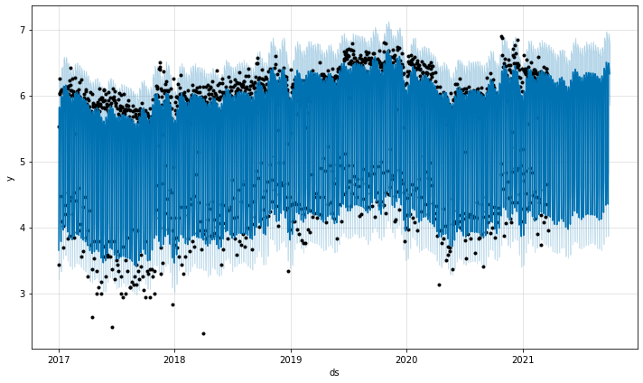

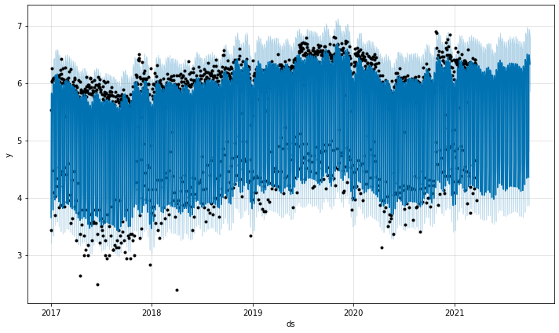

```python
model.plot(forecast_data)
```

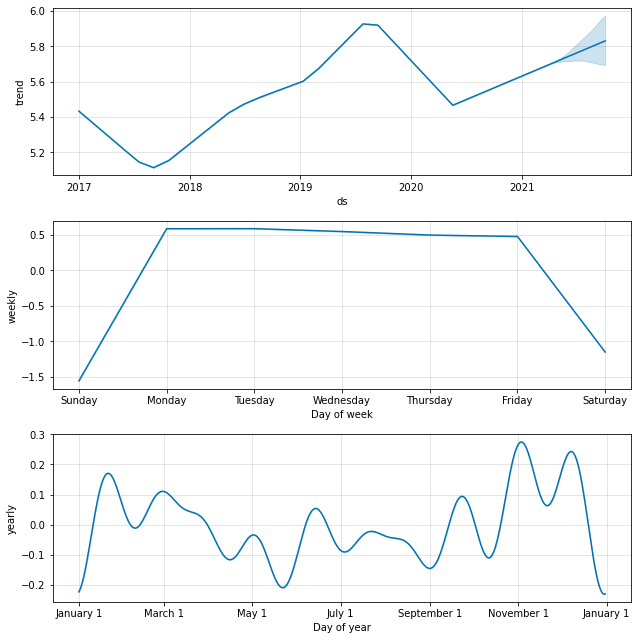

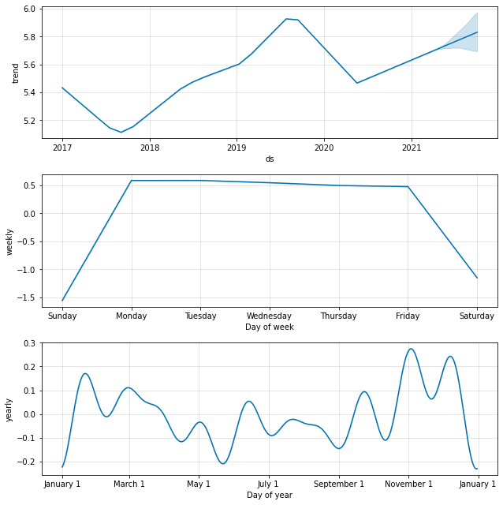

```python
model.plot_components(forecast_data)
```

```python
forecast_data_orig = forecast_data # make sure we save the original forecast data
forecast_data_orig['yhat'] = np.exp(forecast_data_orig['yhat'])
forecast_data_orig['yhat_lower'] = np.exp(forecast_data_orig['yhat_lower'])
forecast_data_orig['yhat_upper'] = np.exp(forecast_data_orig['yhat_upper'])
```

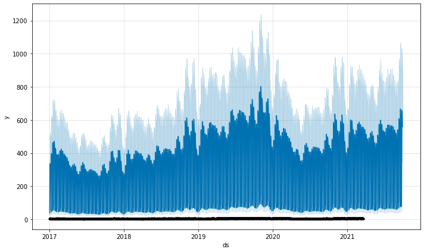

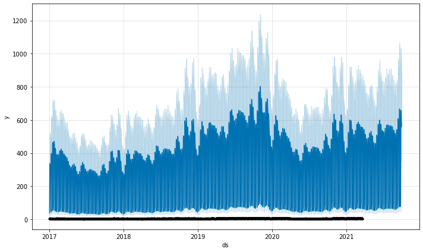

```python
model.plot(forecast_data_orig)
```

```python
df['y_log']=df['y'] #copy the log-transformed data to another column
df['y']=df['y_orig']
```

```python
final_df = pd.DataFrame(forecast_data_orig)
```

```python
final_df.tail(15)
```

|  | ds | trend | yhat_lower | yhat_upper | trend_lower | trend_upper | additive_terms | additive_terms_lower | additive_terms_upper | weekly | weekly_lower | weekly_upper | yearly | yearly_lower | yearly_upper | multiplicative_terms | multiplicative_terms_lower | multiplicative_terms_upper | yhat |
| --- | --- | --- | --- | --- | --- | --- | --- | --- | --- | --- | --- | --- | --- | --- | --- | --- | --- | --- | --- |
| 1719 | 2021-09-17 | 5.819912 | 372.359465 | 917.850068 | 5.698151 | 5.951047 | 0.529006 | 0.529006 | 0.529006 | 0.480142 | 0.480142 | 0.480142 | 0.048863 | 0.048863 | 0.048863 | 0.0 | 0.0 | 0.0 | 571.873319 |
| 1720 | 2021-09-18 | 5.820637 | 69.501516 | 182.757083 | 5.697816 | 5.953312 | -1.089496 | -1.089496 | -1.089496 | -1.151438 | -1.151438 | -1.151438 | 0.061942 | 0.061942 | 0.061942 | 0.0 | 0.0 | 0.0 | 113.424906 |
| 1721 | 2021-09-19 | 5.821362 | 47.378064 | 119.418224 | 5.696946 | 5.953383 | -1.485408 | -1.485408 | -1.485408 | -1.558566 | -1.558566 | -1.558566 | 0.073159 | 0.073159 | 0.073159 | 0.0 | 0.0 | 0.0 | 76.397803 |
| 1722 | 2021-09-20 | 5.822086 | 412.522520 | 1066.680939 | 5.696093 | 5.955157 | 0.671813 | 0.671813 | 0.671813 | 0.589583 | 0.589583 | 0.589583 | 0.082230 | 0.082230 | 0.082230 | 0.0 | 0.0 | 0.0 | 661.095812 |
| 1723 | 2021-09-21 | 5.822811 | 427.397937 | 1039.859271 | 5.695311 | 5.956930 | 0.679310 | 0.679310 | 0.679310 | 0.590392 | 0.590392 | 0.590392 | 0.088917 | 0.088917 | 0.088917 | 0.0 | 0.0 | 0.0 | 666.553648 |
| 1724 | 2021-09-22 | 5.823536 | 414.106255 | 1019.152685 | 5.695384 | 5.958703 | 0.643021 | 0.643021 | 0.643021 | 0.549980 | 0.549980 | 0.549980 | 0.093040 | 0.093040 | 0.093040 | 0.0 | 0.0 | 0.0 | 643.264870 |
| 1725 | 2021-09-23 | 5.824261 | 388.584694 | 968.108544 | 5.695548 | 5.960477 | 0.594384 | 0.594384 | 0.594384 | 0.499906 | 0.499906 | 0.499906 | 0.094477 | 0.094477 | 0.094477 | 0.0 | 0.0 | 0.0 | 613.171172 |
| 1726 | 2021-09-24 | 5.824985 | 381.752678 | 937.758392 | 5.695728 | 5.962250 | 0.573316 | 0.573316 | 0.573316 | 0.480142 | 0.480142 | 0.480142 | 0.093174 | 0.093174 | 0.093174 | 0.0 | 0.0 | 0.0 | 600.823458 |
| 1727 | 2021-09-25 | 5.825710 | 73.110863 | 183.123006 | 5.695448 | 5.963835 | -1.062294 | -1.062294 | -1.062294 | -1.151438 | -1.151438 | -1.151438 | 0.089144 | 0.089144 | 0.089144 | 0.0 | 0.0 | 0.0 | 117.145477 |
| 1728 | 2021-09-26 | 5.826435 | 47.842888 | 122.849873 | 5.694506 | 5.964822 | -1.476091 | -1.476091 | -1.476091 | -1.558566 | -1.558566 | -1.558566 | 0.082475 | 0.082475 | 0.082475 | 0.0 | 0.0 | 0.0 | 77.505108 |
| 1729 | 2021-09-27 | 5.827160 | 406.453331 | 1033.383702 | 5.694560 | 5.965778 | 0.662907 | 0.662907 | 0.662907 | 0.589583 | 0.589583 | 0.589583 | 0.073324 | 0.073324 | 0.073324 | 0.0 | 0.0 | 0.0 | 658.566965 |
| 1730 | 2021-09-28 | 5.827884 | 414.156080 | 1021.790586 | 5.694551 | 5.967814 | 0.652307 | 0.652307 | 0.652307 | 0.590392 | 0.590392 | 0.590392 | 0.061915 | 0.061915 | 0.061915 | 0.0 | 0.0 | 0.0 | 652.095537 |
| 1731 | 2021-09-29 | 5.828609 | 389.972830 | 985.774080 | 5.694238 | 5.970301 | 0.598518 | 0.598518 | 0.598518 | 0.549980 | 0.549980 | 0.549980 | 0.048538 | 0.048538 | 0.048538 | 0.0 | 0.0 | 0.0 | 618.394996 |
| 1732 | 2021-09-30 | 5.829334 | 357.198668 | 913.590613 | 5.693965 | 5.971958 | 0.533448 | 0.533448 | 0.533448 | 0.499906 | 0.499906 | 0.499906 | 0.033541 | 0.033541 | 0.033541 | 0.0 | 0.0 | 0.0 | 579.857060 |
| 1733 | 2021-10-01 | 5.830059 | 346.527537 | 882.517610 | 5.693404 | 5.974359 | 0.497466 | 0.497466 | 0.497466 | 0.480142 | 0.480142 | 0.480142 | 0.017324 | 0.017324 | 0.017324 | 0.0 | 0.0 | 0.0 | 559.769317 |

Display only 2 colums that we have to needed one is ds, and other is yhat

## Predictions

```python
final_df[['ds','yhat']].tail(15)
```

|  | ds | yhat |
| --- | --- | --- |
| 1719 | 2021-09-17 | 571.873319 |
| 1720 | 2021-09-18 | 113.424906 |
| 1721 | 2021-09-19 | 76.397803 |
| 1722 | 2021-09-20 | 661.095812 |
| 1723 | 2021-09-21 | 666.553648 |
| 1724 | 2021-09-22 | 643.264870 |
| 1725 | 2021-09-23 | 613.171172 |
| 1726 | 2021-09-24 | 600.823458 |
| 1727 | 2021-09-25 | 117.145477 |
| 1728 | 2021-09-26 | 77.505108 |
| 1729 | 2021-09-27 | 658.566965 |
| 1730 | 2021-09-28 | 652.095537 |
| 1731 | 2021-09-29 | 618.394996 |
| 1732 | 2021-09-30 | 579.857060 |
| 1733 | 2021-10-01 | 559.769317 |

```python
import plotly.graph_objs as go
import plotly.offline as py
```

```python
#Plot predicted and actual line graph with X=dates, Y=Outbound
actual_chart = go.Scatter(y=df["y_orig"], name= 'Actual')
predict_chart = go.Scatter(y=final_df["yhat"], name= 'Predicted')
predict_chart_upper = go.Scatter(y=final_df["yhat_upper"], name= 'Predicted Upper')
predict_chart_lower = go.Scatter(y=final_df["yhat_lower"], name= 'Predicted Lower')
py.plot([actual_chart, predict_chart, predict_chart_upper, predict_chart_lower], image_width=400, image_height=400)
#py.plot([actual_chart, predict_chart, predict_chart_upper, predict_chart_lower], filename = 'templates/' +'filename.html', auto_open=False)
```

```
'temp-plot.html'
```

```python
df = final_df.rename(columns={'yhat':'CC Volume', 'ds':'DATE'}) # change the name of columns and set the orignal name
```

```python
df[['DATE','CC Volume']].tail(20)
```

|  | DATE | CC Volume |
| --- | --- | --- |
| 1714 | 2021-09-12 | 68.396280 |
| 1715 | 2021-09-13 | 596.650793 |
| 1716 | 2021-09-14 | 607.855774 |
| 1717 | 2021-09-15 | 593.999966 |
| 1718 | 2021-09-16 | 574.406921 |
| 1719 | 2021-09-17 | 571.873319 |
| 1720 | 2021-09-18 | 113.424906 |
| 1721 | 2021-09-19 | 76.397803 |
| 1722 | 2021-09-20 | 661.095812 |
| 1723 | 2021-09-21 | 666.553648 |
| 1724 | 2021-09-22 | 643.264870 |
| 1725 | 2021-09-23 | 613.171172 |
| 1726 | 2021-09-24 | 600.823458 |
| 1727 | 2021-09-25 | 117.145477 |
| 1728 | 2021-09-26 | 77.505108 |
| 1729 | 2021-09-27 | 658.566965 |
| 1730 | 2021-09-28 | 652.095537 |
| 1731 | 2021-09-29 | 618.394996 |
| 1732 | 2021-09-30 | 579.857060 |
| 1733 | 2021-10-01 | 559.769317 |

```python
df.columns #chack the total columns on our dataset
```

```
Index(['DATE', 'trend', 'yhat_lower', 'yhat_upper', 'trend_lower',
       'trend_upper', 'additive_terms', 'additive_terms_lower',
       'additive_terms_upper', 'weekly', 'weekly_lower', 'weekly_upper',
       'yearly', 'yearly_lower', 'yearly_upper', 'multiplicative_terms',
       'multiplicative_terms_lower', 'multiplicative_terms_upper',
       'CC Volume'],
      dtype='object')
```

#### Remove the uncessery columns in our dataset only use 2 coulmns(DATE,CC Volumne) that we have to needed

```python
df.drop(['trend', 'yhat_lower', 'yhat_upper', 'trend_lower',
       'trend_upper', 'additive_terms', 'additive_terms_lower',
       'additive_terms_upper', 'weekly', 'weekly_lower', 'weekly_upper',
       'yearly', 'yearly_lower', 'yearly_upper', 'multiplicative_terms',
       'multiplicative_terms_lower', 'multiplicative_terms_upper'],axis = 1)
```

|  | DATE | CC Volume |
| --- | --- | --- |
| 0 | 2017-01-01 | 38.537120 |
| 1 | 2017-01-02 | 333.235880 |
| 2 | 2017-01-03 | 337.894591 |
| 3 | 2017-01-04 | 329.977160 |
| 4 | 2017-01-05 | 320.164342 |
| ... | ... | ... |
| 1729 | 2021-09-27 | 658.566965 |
| 1730 | 2021-09-28 | 652.095537 |
| 1731 | 2021-09-29 | 618.394996 |
| 1732 | 2021-09-30 | 579.857060 |
| 1733 | 2021-10-01 | 559.769317 |

1734 rows × 2 columns

#### Export Pandas DataFrame to a CSV File

```python
df.to_csv('Future_forecast.csv', index=False) # tranfoer
```

# Time series forecasting using ARIMA Model

ARIMA models are, in theory, the most general class of models for forecasting a time series, which can be made to be “stationary” by differencing (if necessary), perhaps in conjunction with nonlinear transformations such as logging or deflating (if necessary). A random variable that is a time series is stationary if its statistical properties are all constant over time. A stationary series has no trend, its variations around its mean have a constant amplitude, and it wiggles in a consistent fashion, i.e., its short-term random time patterns always look the same in a statistical sense. The latter condition means that its autocorrelations (correlations with its prior deviations from the mean) remain constant over time, or equivalently, that its power spectrum remains constant over time. A random variable of this form can be viewed (as usual) as a combination of signal and noise, and the signal (if one is apparent) could be a pattern of fast or slow mean reversion, or sinusoidal oscillation, or rapid alternation in sign, and it could also have a seasonal component. An ARIMA model can be viewed as a “filter” that tries to separate the signal from the noise, and the signal is then extrapolated into the future to obtain forecasts.

### Import Packages

In addition to Statsmodels, we will need to import additional packages, including Numpy, Scipy, Pandas, and Matplotlib.

Also, from Statsmodels we will need to import qqplot.

```python
import numpy as np
import pandas as pd
from scipy import stats
import statsmodels.api as sm
import matplotlib.pyplot as plt
from statsmodels.graphics.api import qqplot
```

```python
dta= pd.read_excel("DATAset after Filtering.xlsx")
dta.head(10)
```

|  | Daily / Cumulative | Indicator | Date | Event | City | Region | Cases (person) |
| --- | --- | --- | --- | --- | --- | --- | --- |
| 0 | Daily | Cases | 2020-03-09 | flights suspended to number of countries | Ar Riyad | Ar Riyad | 1 |
| 1 | Daily | Cases | 2020-03-13 | NaN | Ar Riyad | Ar Riyad | 3 |
| 2 | Daily | Cases | 2020-03-14 | NaN | Ar Riyad | Ar Riyad | 12 |
| 3 | Daily | Cases | 2020-03-15 | International flights suspension for 14 days | Ar Riyad | Ar Riyad | 2 |
| 4 | Daily | Cases | 2020-03-16 | Gov / private suspension | Ar Riyad | Ar Riyad | 4 |
| 5 | Daily | Cases | 2020-03-17 | NaN | Ar Riyad | Ar Riyad | 19 |
| 6 | Daily | Cases | 2020-03-18 | NaN | Ar Riyad | Ar Riyad | 19 |
| 7 | Daily | Cases | 2020-03-19 | NaN | Ar Riyad | Ar Riyad | 21 |
| 8 | Daily | Cases | 2020-03-20 | NaN | Ar Riyad | Ar Riyad | 49 |
| 9 | Daily | Cases | 2020-03-21 | Domestic flights suspension | Ar Riyad | Ar Riyad | 36 |

```python
dta.shape
```

```
(355, 7)
```

```python
dta.info()
```

```
<class 'pandas.core.frame.DataFrame'>
RangeIndex: 355 entries, 0 to 354
Data columns (total 7 columns):
 #   Column              Non-Null Count  Dtype
---  ------              --------------  -----
 0   Daily / Cumulative  355 non-null    object
 1   Indicator           355 non-null    object
 2   Date                355 non-null    datetime64[ns]
 3   Event               12 non-null     object
 4   City                355 non-null    object
 5   Region              355 non-null    object
 6   Cases (person)      355 non-null    int64
dtypes: datetime64[ns](1), int64(1), object(5)
memory usage: 19.5+ KB
```

### Data Preprocessing

```python
# Remove columns which are not required in predictions

cols = ['Daily / Cumulative', 'Indicator', 'Event', 'City','Region']
dta.drop(cols, axis = 1, inplace = True)
dta.head()
```

|  | Date | Cases (person) |
| --- | --- | --- |
| 0 | 2020-03-09 | 1 |
| 1 | 2020-03-13 | 3 |
| 2 | 2020-03-14 | 12 |
| 3 | 2020-03-15 | 2 |
| 4 | 2020-03-16 | 4 |

```python
# Sort the Date
dta = dta.sort_values('Date')
#check any missing values
dta.isnull().sum()
```

```
Date              0
Cases (person)    0
dtype: int64
```

```python
dta.info()
```

```
<class 'pandas.core.frame.DataFrame'>
Int64Index: 355 entries, 0 to 354
Data columns (total 2 columns):
 #   Column          Non-Null Count  Dtype
---  ------          --------------  -----
 0   Date            355 non-null    datetime64[ns]
 1   Cases (person)  355 non-null    int64
dtypes: datetime64[ns](1), int64(1)
memory usage: 8.3 KB
```

```python
# grouping sales according to Date
dta.groupby('Date')['Cases (person)'].sum()

# min and max values of  Date
print(dta['Date'].min())
print(dta['Date'].max())
```

```
2020-03-09 00:00:00
2021-03-01 00:00:00
```

```python
#set 'Date' as index
dta_df = dta.set_index('Date')
dta_df.index
```

```
DatetimeIndex(['2020-03-09', '2020-03-13', '2020-03-14', '2020-03-15',
               '2020-03-16', '2020-03-17', '2020-03-18', '2020-03-19',
               '2020-03-20', '2020-03-21',
               ...
               '2021-02-20', '2021-02-21', '2021-02-22', '2021-02-23',
               '2021-02-24', '2021-02-25', '2021-02-26', '2021-02-27',
               '2021-02-28', '2021-03-01'],
              dtype='datetime64[ns]', name='Date', length=355, freq=None)
```

```python
dta_df.head(10)
```

| Date | Cases (person) |
| --- | --- |
| 2020-03-09 | 1 |
| 2020-03-13 | 3 |
| 2020-03-14 | 12 |
| 2020-03-15 | 2 |
| 2020-03-16 | 4 |
| 2020-03-17 | 19 |
| 2020-03-18 | 19 |
| 2020-03-19 | 21 |
| 2020-03-20 | 49 |
| 2020-03-21 | 36 |

```python
# average the daily cases value for each month
# use start of each month as the timestamp
y = dta_df['Cases (person)'].resample('MS').mean()
y['2020':]
```

```
Date
2020-03-01     28.650000
2020-04-01    131.600000
2020-05-01    522.129032
2020-06-01    864.866667
2020-07-01    216.258065
2020-08-01     67.903226
2020-09-01     36.133333
2020-10-01     33.193548
2020-11-01     54.666667
2020-12-01     34.032258
2021-01-01     46.419355
2021-02-01    105.214286
2021-03-01    119.000000
Freq: MS, Name: Cases (person), dtype: float64
```

### Data Visualization

```python
import matplotlib
plt.style.use('fivethirtyeight')
matplotlib.rcParams['axes.labelsize'] = 14
matplotlib.rcParams['xtick.labelsize'] = 12
matplotlib.rcParams['ytick.labelsize'] = 12
matplotlib.rcParams['text.color'] = 'k'
```

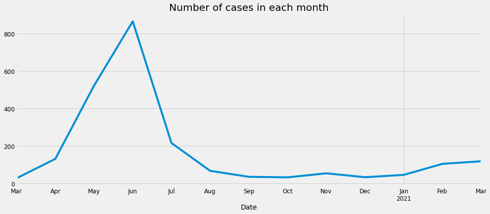

```python
y.plot(figsize = (15, 6))
plt.title("Number of cases in each month")
plt.show()
```

### Time-series decompositon

It allows us to decompose our time series into three distinct components

> Trend

> Seasonality

> Noise

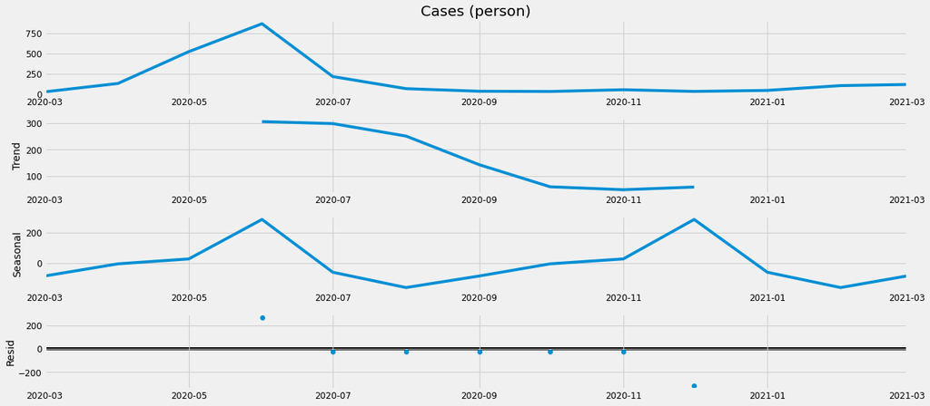

```python
from pylab import rcParams
rcParams['figure.figsize'] = 18, 8

decomposition = sm.tsa.seasonal_decompose(y, model = 'additive',period = int(len(y)/2))
fig = decomposition.plot()
plt.show()
```

*About ARIMA model*

- ARIMA stands for *Autoregressive Integreted Moving Average*
- ARIMA models are denoted with the notation *ARIMA(p, d, q)*
- These three parameters account for *seasonality, trend, and noise* in data

# ARIMA Model

**ARIMA as a feature:**

ARIMA is a technique for predicting time series data. We will show how to use it, and all though ARIMA will not serve as our final prediction, we will use it as a technique to denoise the stock a little and to (possibly) extract some new patters or features.

**ARIMA is an acronym. This acronym is descriptive, capturing the key aspects of the model itself. Briefly, they are:**

1. `AR: Autoregression`. A model that uses the dependent relationship between an observation and some number of lagged observations.
2. `I: Integrated`. The use of differencing of raw observations (e.g. subtracting an observation from an observation at the previous time step) in order to make the time series stationary.
3. `MA: Moving Average`. A model that uses the dependency between an observation and a residual error from a moving average model applied to lagged observations.

**The parameters of the ARIMA model are defined as follows:**

> `p:` The number of lag observations included in the model, also called the lag order.

> `d:` The number of times that the raw observations are differenced, also called the degree of differencing.

> `q:` The size of the moving average window, also called the order of moving average.

**STEPS FOR ARIMA**

1. Define the model by calling `ARIMA()` and passing in the p, d, and q parameters.
2. The model is prepared on the training data by calling the `fit()` function.
3. Predictions can be made by calling the `predict()` function and specifying the index of the time or times to be predicted.